# Quant: Final Assignment

Sage Voorhees

10/14/2020

```r
# Run Libararies
library(tidycensus)
library(tidyverse)
library(ggplot2)
library(ggthemes)
library(sf)
library(ggspatial)
library(units)
library(nngeo)
library(gridExtra)
library(jtools)
library(interactions)
library(formattable)
library(cowplot)
library(gghighlight)
library(osmdata)
library(opentripplanner)
library(tidyverse)
library(sf)
library(ggthemes)
library(ggspatial)
library(tidygeocoder)
library(ggmap)
library(rgeos)
library(qwraps2)
library(latexpdf)
```

# **Understanding Rent Burden In Albuquerque**

## **Introduction**

When we think about Rent Burden in the United States, a quick scan through newspaper headlines and conference keynotes will show you that Rent Burden is most frequently framed in the context of coastal cities: Los Angeles, New York City, San Francisco, Boston. Often, rightfully so, rent is eye-catching in these areas—but as folks interested in the well-being of Burqueños—we must acknowledge that rent burden is something that affects our city too. According to a 2019 report by the National Low Income Housing Coalition, there is “not a single county in the united states where a worker earning the federal or prevailing minimum wage could afford a modest two-bedroom rental home by working a standard 40-hr workweek.” Albuquerque is no exception. According to the report, for an individual making 7.25$ an hour (federal minimum wage) they would need to work 127 hours per week in order to afford an average two-bedroom without being rent-burdened (spending more than 30% of their income on rent). While thanks to a recent raise in minimum wage, Albuquerque’s minimum wage is now 9.25$/hr, the average one-bedroom apartment is $750 in 2020 according to Zumper, an 8% increase from last year. This means that someone would need to work 68+ hours/week to afford an average one-bedroom apartment in Albuquerque. Furthermore, a recent report between Mayor Keller’s office and the Urban Institute show that while rental units increases from 2006-2012 by about 8,400, the number of rental units affordable to renter households with extremely low incomes decreased by 700 (from 7,600 to 6,900).

This analysis begins to take a look at Rent Burden in Albuquerque. The analysis hopes to shed light on who is rent-burdened in the city, where they live and what they have in common. This analysis also hopes to put itself in conversation with potential policies that could address rent burden, like the recently adopted changes in the city’s zoning code to expand where casitas (accessory dwelling units) may be constructed.

The hypothesis that led this report is that there are factors (such as race & ethnicity, neighborhood, and education level) that correlate with who is rent burdened in the city. A further narrowing down of this hypothesis is that these correlations will vary within different areas of the city (ie that variables like education will have a bigger affect on rent burden in areas like Kirtland AFB than it does on areas like the South Valley)

```r
opq(bbox = 'Albuquerque, NM USA') %>%
  add_osm_feature(key = 'highway') %>%
  osmdata_xml(file = 'OTP/graphs/default/abq_streets.osm')
```

```r
abq_street_features <- opq(bbox = 'Albuquerque,NM USA') %>%
  add_osm_feature(key = 'highway') %>%
  osmdata_sf()
abq_streets <- abq_street_features$osm_lines
```

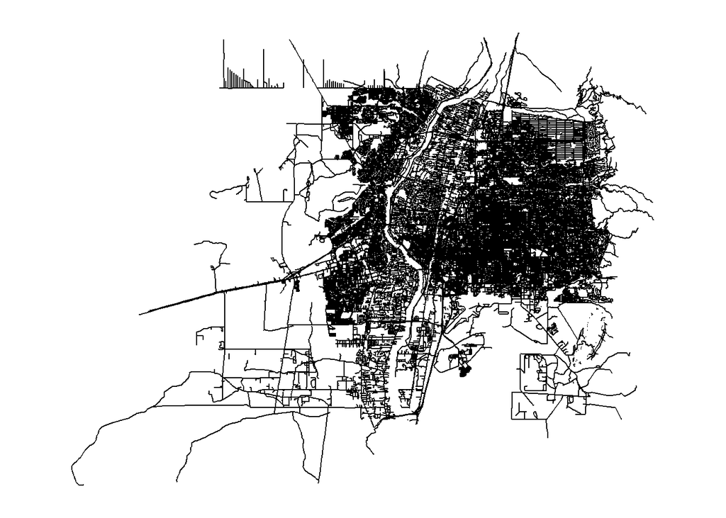

```r
ggplot(abq_streets) +
  geom_sf() +
  theme_map()
```

```r
### **Load & Adjust Variables**

#Load Data Frame from CSV
assignment6_vars <- read_csv("New_Mexico_Vars_Development")

assignment6_vars <-assignment6_vars %>%

 #Filter for Only Bernalillo COunty
  filter(PUMA == 00801|
         PUMA == 00802|
         PUMA == 00803|
         PUMA == 00804|
         PUMA == 00805|
         PUMA == 00806) %>%


#Mutate PUMA LABEL
   mutate(PUMA_label = case_when(PUMA == 00801 ~ " 1 Northeast Heights",
                                   PUMA == 00802 ~ "Southeast Heights",
                                   PUMA == 00803 ~ "Kirtland AFB/Gibson",
                                   PUMA == 00804 ~ "Downtown, Nob Hill, N.Valley",
                                   PUMA == 00805 ~ "Rio Rancho",
                                   PUMA == 00806 ~ "South Valley")) %>%


#Mutate Building Type
  mutate(bld_type =case_when(
                        BLD_label == "One-family house detached" ~ "1 Family Home",
                        BLD_label == "One-family house attached" ~ "1 Family Home",
                        BLD_label == "2 Apartments" ~ "Apartment",
                        BLD_label == "Mobile home or trailer" ~ "Mobile Home/Trailer/5th Wheel",
                        BLD_label == "3-4 Apartments" ~ "Apartment",
                        BLD_label == "5-9 Apartments" ~ "Apartment",
                        BLD_label == "10-19 Apartments" ~ "Apartment",
                        BLD_label == "20-49 Apartments" ~ "Apartment",
                        BLD_label == "50 or more apartments" ~ "Apartment",
                        BLD_label == "Boat, RV, van, etc." ~"Mobile Home/Trailer/5th Wheel",
                        TRUE ~ "Other" )) %>%

#Mutate YBL to Decade House Was Built
  mutate(when_built = case_when(
                        YBL_label == "1939 or earlier" ~ "1 pre 1940",
                        YBL_label == "1940 to 1949" ~ "1.2 40s/50s",
                        YBL_label == "1950 to 1959" ~ "1.2 40s/50s",
                        YBL_label == "1960 to 1969" ~ "1.3 60s/70s",
                        YBL_label == "1970 to 1979" ~ "1.3 60s/70s",
                        YBL_label == "1980 to 1989" ~ "1.4 80s/90s",
                        YBL_label == "1990 to 1999" ~ "1.4 80s/90s",
                        YBL_label == "2000 to 2004" ~ "2000s/10s",
                        YBL_label == "2005"~ "2000s/10s" ,
                        YBL_label == "2006"~ "2000s/10s" ,
                        YBL_label == "2007"~ "2000s/10s" ,
                        YBL_label == "2008"~ "2000s/10s",
                        YBL_label == "2009" ~ "2000s/10s",
                               YBL_label == "2010" ~ "2000s/10s",
                               YBL_label == "2011" ~ "2000s/10s",
                               YBL_label == "2012" ~ "2000s/10s",
                               YBL_label == "2013" ~ "2000s/10s",
                               YBL_label == "2014" ~ "2000s/10s",
                               YBL_label == "2015" ~ "2000s/10s",
                               YBL_label == "2016" ~ "2000s/10s",
                               YBL_label == "2017" ~ "2000s/10s",
                               YBL_label == "2018" ~ "2000s/10s",
                        TRUE ~"Other")) %>%

    mutate(when_built_simp = case_when(
                        when_built == "2000s/10s" ~ "Last Twenty",
                        when_built != "2000s/10s" ~ "Older",
                        TRUE ~"Data not available")) %>%

#Journey to Work as a Categorical Variable
mutate(JWMNP_binned = case_when(
          JWMNP <15 ~ "0 - 15 minutes",
          JWMNP <30 & JWMNP >15 | JWMNP == 15 ~ "15 - 30 minutes",
          JWMNP >30 & JWMNP <45 | JWMNP == 45 ~ "30 - 45 minutes",
          JWMNP >45 & JWMNP <60 | JWMNP == 60 ~ "45 - 60 minutes",
          JWMNP >60 & JWMNP <75 | JWMNP == 75 ~ "60 - 75 minutes",
          TRUE ~ "No Commute Reported")) %>%

#Household Size Simplified
mutate(NP_simp = case_when(
          NP == 1 ~ "1 person",
          NP == 2 ~ "2 people",
          NP > 3 | NP == 3 ~ "3+ people",
          TRUE ~ "Data Not Reported")) %>%

  #Household Size: Binary
mutate(NP_binary = case_when(
          NP == 1 ~ "1 person",
          NP > 2 | NP == 2 ~ "2+ people",
          TRUE ~ "Data Not Reported")) %>%

# Rent Burden Simplified
   mutate(GRPIP_simp = case_when(
          GRPIP <30 ~ "Not Rent Burdened",
          GRPIP >30 & GRPIP <50 | GRPIP == 30 ~ "Rent Burdened",
          GRPIP >50 | GRPIP == 45 ~ "Severely Rent Burdened",
          TRUE ~ "Data Not Reported")) %>%



#Recode Race & Ethnicity Together
  mutate(race_ethn = case_when(

    #WHITE
   RAC1P == "1" & HISP == "01" ~ "1 White (NH)",
   RAC1P == "1" & HISP != "01" ~ "Hispanic (White))",

   #NATIVE AMERICAN (inc Alaska Native)

   RAC1P == "3" & HISP == "01" ~ "Native American",
   RAC1P == "3" & HISP != "01" ~"Native American",

   RAC1P == "7" & HISP == "01" ~ "Native American",
   RAC1P == "7" & HISP != "01"~ "Native American",

   RAC1P == "9" & HISP == "01" ~ "Native American",
   RAC1P == "9" & HISP != "01" ~"Native American",

   #AFRICAN AMERICAN / BLACK
    RAC1P == "4" & HISP == "01" ~ "Black/AA",
    RAC1P == "4" & HISP != "01" ~ "Black/AA",

   #ASIAN
   RAC1P =="6" & HISP == "01" ~ "Asian",
   RAC1P =="6" & HISP != "01" ~ "Asian",

   #SOME OTHER RACE ALONE & MULTIRACIAL

   RAC1P == "2" & HISP == "01" ~ "Other Race or Multiracial (NH)",
   RAC1P == "2" & HISP != "01"~ "Hispanic (Non-White)",

   RAC1P == "5" & HISP == "01" ~ "Other Race or Multiracial (NH)",
   RAC1P == "5" & HISP != "01"~ "Hispanic (Non-White)",

   #Native Hawaiian, Pacific Islander --> Coded as Other Race
   RAC1P == "8" & HISP == "01" ~ "Other Race or Multiracial (NH)",
   RAC1P == "8" & HISP != "01" ~ "Hispanic (Non-White)",

   # Other
   TRUE ~ "Other"))%>%

mutate(income_per_person = HINCP/NP) %>%
   # Simplify Education (Thank you Emma Colley for inspiring this breakdown)
   mutate(SCHL_simp = case_when(
    SCHL_label=="1 or more years of college credit, no degree"~"1 HS Diploma",
    SCHL_label=="12th grade - no diploma"~"Some HS, No Diploma",
    SCHL_label=="Associate's degree"~"Assoc. Degree",
    SCHL_label=="Bachelor's degree"~"Bach Degree or Higher",
    SCHL_label=="Doctorate degree"~"Bach Degree or Higher",
    SCHL_label=="GED or alternative credential"~"1 HS Diploma",
    SCHL_label=="Grade 10"~"Some HS, No Diploma",
    SCHL_label=="Grade 11"~"Some HS, No Diploma",
    SCHL_label=="Grade 1"~"No HS",
    SCHL_label=="Grade 2"~"No HS",
    SCHL_label=="Grade 3"~"No HS",
    SCHL_label=="Grade 4"~"No HS",
    SCHL_label=="Grade 5"~"No HS",
    SCHL_label=="Grade 6"~"No HS",
    SCHL_label=="Grade 7"~"No HS",
    SCHL_label=="Grade 8"~"No HS",
    SCHL_label=="Grade 9"~"Some HS, No Diploma",
    SCHL_label=="Kindergarten"~"No HS",
    SCHL_label=="Master's degree"~"Bach Degree or Higher",
    SCHL_label=="No schooling completed"~"No HS",
    SCHL_label=="Nursery school, preschool"~"No HS",
    SCHL_label=="Professional degree beyond a bachelor's degree"~"Bach Degree or Higher",
    SCHL_label=="Regular high school diploma"~"1 HS Diploma",
    SCHL_label=="Some college, but less than 1 year"~"1 HS Diploma")) %>%



dplyr::select(HINCP, race_ethn, RAC1P_label, HISP_label, JWMNP_binned, NP,  NP_simp, NP_binary, PUMA_label, when_built, when_built_simp, AGEP, bld_type, BLD_label, PINCP, BLD_label, GRPIP, GRPIP_simp, RNTP, income_per_person, SCHL_simp, RNTP)
```

```r
### **Create Neighborhood Specific Vars**
# ABQ RENTERS
ass6_ABQs_renters <- assignment6_vars %>%
  filter(RNTP != 0)


# 801: NORTHEAST HEIGHTS
## ALL
ass6_NEHeights <- assignment6_vars %>%
  filter(PUMA_label == " 1 Northeast Heights")

## JUST RENTERS
ass6_NEHeights_renters <- assignment6_vars %>%
  filter(PUMA_label == " 1 Northeast Heights") %>%
  filter(RNTP != 0)


# 802: SOUTHEAST HEIGHTS
## ALL
ass6_SEHeights <- assignment6_vars %>%
  filter(PUMA_label == "Southeast Heights")

## JUST RENTERS
ass6_SEHeights_renters <- assignment6_vars %>%
  filter(PUMA_label == "Southeast Heights") %>%
  filter(RNTP != 0)


# 803: KAFB/GIBSON
## ALL
ass6_KAFB <- assignment6_vars %>%
  filter(PUMA_label == "Kirtland AFB/Gibson")

## JUST RENTERS
ass6_KAFB_renters <- assignment6_vars %>%
  filter(PUMA_label == "Kirtland AFB/Gibson") %>%
  filter(RNTP != 0)


# 804: KAFB/GIBSON
## ALL
ass6_DT_NH_NV <- assignment6_vars %>%
  filter(PUMA_label == "Downtown, Nob Hill, N.Valley")

## JUST RENTERS
ass6_DT_NH_NV_renters <- assignment6_vars %>%
  filter(PUMA_label == "Downtown, Nob Hill, N.Valley") %>%
  filter(RNTP != 0)


# 805: RIO RANCHO
## ALL
ass6_RIO_R <- assignment6_vars %>%
  filter(PUMA_label == "Rio Rancho")

## JUST RENTERS
ass6_RIO_R_renters <- assignment6_vars %>%
  filter(PUMA_label == "Rio Rancho") %>%
  filter(RNTP != 0)


## # 806: SOUTH VALLEY
## ALL
ass6_SVALLEY <- assignment6_vars %>%
  filter(PUMA_label == "South Valley")

## JUST RENTERS
ass6_SVALLEY_renters <- assignment6_vars %>%
  filter(PUMA_label == "Rio Rancho") %>%
  filter(RNTP != 0)
```

## **Data**

Within the analysis, I use the following sub-categorization of the ACS-2018 data.

```r
Dataframe_Breakdown <- data.frame(
  'Sub-Category' = c("Albuquerque Total", "Albuquerque Renters", "Northeast Heights", "Northeast Heights Renters", "Southeast Heights", "Southeast Heights Renters", "Kirtland Airforce Base/Gibson",  "Kirtland Airforce Base/Gibson Renters", "Downtown/Nob Hill/North Valley","Downtown/Nob Hill/North Valley Renters", "Rio Rancho", "Rio Rancho Renters", "South Valley", "South Valley Renters"),
  'Observations' = c(16054,1372,807,199,935,271,718, 294,783,256,952,202, 687,202))



formattable(Dataframe_Breakdown)
```

[output not shown]

In the analysis, I created & looked at the following 14 variables. Not all variables were used in final linear regression models, but all were used at some point as a way of exploring the data.

```r
Variables <- data.frame(
  'Variable' = c("Rent Burden", "Rent Burden: Categorized", "Commute to Work", "Household Size", "Rental Type", "Decade Rental Constructed", "Household Income", "Personal Income", "Household Income per Person", "Age of Renter", "Education",  "Rent", "Race & Ethnicity", "Neighborhood"),
  'Variable Name' = c("GRPIP", "GRPIP_simp", "JWMNP_binned", "NP_simp", "bld_type", "when_built", "HINCP", "PINCP", "income_per_person", "AGEP", "SCHL_simp", "RNTP", "race_ethn", "PUMA_label"),
  'Variable Type' = c("Continuous","Categorical","Categorical","Categorical","Categorical","Categorical","Categorical","Categorical","Categorical","Continuous","Continuous", "Continuous", "Categorical", "Categorical"),
  'Alterations' = c("None", "Binned into 3 Categories", "Binned into 15 minute intervals", "Binned into 3 categories", "Aggregated into larger categories", "Aggregated into 20 year periods", "None", "None", "Divided Household Income by Household Size", "None", "Aggregated into larger categories", "None", "Combined RINCP & HISP", "Created names for PUMA areas"))



formattable(Variables)
```

[output not shown]

### **Albuquerque Demographics**

#### Below are some visualizations of the variables and data used in this analysis.

#### **1. Rent Burden**

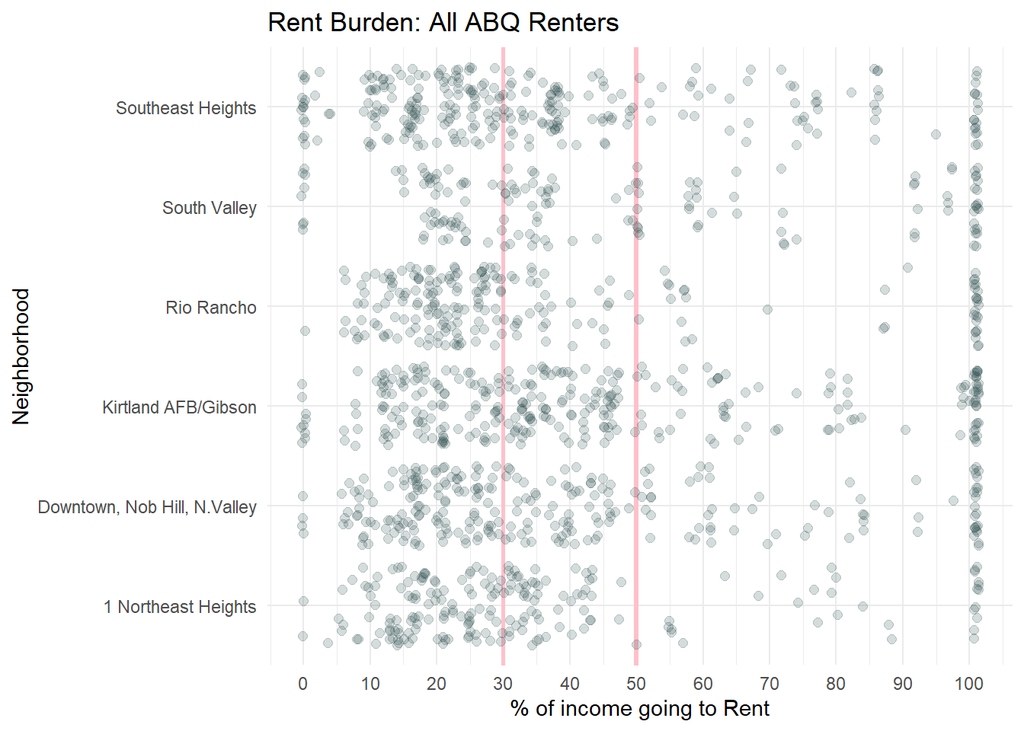

```r
ggplot(ass6_ABQs_renters, aes(x=GRPIP, y=PUMA_label)) +

  geom_segment( y=200,
                yend=0,
                x=30,
                xend=30,
                size =1,
                alpha=.4,
                color ="pink") +

geom_segment( y=200,
                yend=0,
                x=50,
                xend=50,
                alpha=.8,
                size =1.2,
                color ="pink") +

  labs(title="Rent Burden: All ABQ Renters")  +
  geom_point(position = "jitter", size =2, alpha =.2, color = "darkslategray") +
  scale_y_discrete(name="Neighborhood") +
  scale_x_continuous(name ="% of income going to Rent",
                     breaks = seq(0,101, by = 10),
                     labels = paste(seq(0,101, by = 10),
                     "", sep = "")) +

   theme_minimal()
```

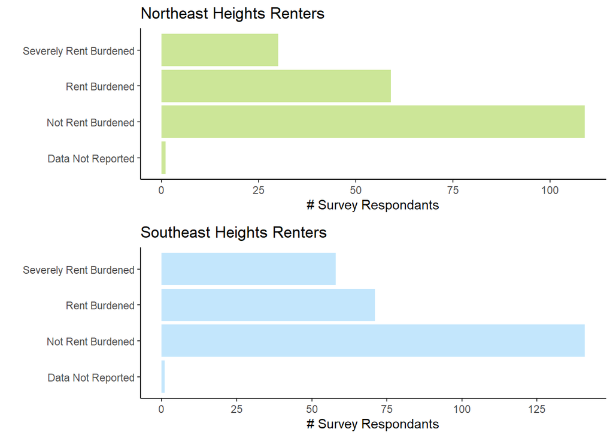

```r
rb_NEH <-  ggplot(ass6_NEHeights_renters, aes(x =GRPIP_simp)) +
   labs(title="Northeast Heights Renters")  +
  geom_bar(fill="olivedrab3", alpha =.5) +
   theme(axis.text.x = element_text(angle = 90)) +
   scale_x_discrete(name="") +
    scale_y_continuous(name= "# Survey Respondants",
                       breaks = seq(0,1000, by = 25),
                     labels = paste(seq(0,1000, by = 25),
                     "", sep = "")) +
   coord_flip() +
  theme_classic()




RB_SEH <-  ggplot(ass6_SEHeights_renters, aes(x =GRPIP_simp)) +
   labs(title="Southeast Heights Renters")  +
  geom_bar(fill="lightskyblue", alpha =.5) +
   theme(axis.text.x = element_text(angle = 90)) +
   scale_x_discrete(name="") +
       scale_y_continuous(name= "# Survey Respondants",
                       breaks = seq(0,1000, by = 25),
                     labels = paste(seq(0,1000, by = 25),
                     "", sep = "")) +
   coord_flip() +
  theme_classic()

RB_KAFB <-  ggplot(ass6_KAFB_renters, aes(x =GRPIP_simp)) +
   labs(title="Kirtland AirForce Base/Gibson")  +
  geom_bar(fill="lightskyblue", alpha =.5) +
   theme(axis.text.x = element_text(angle = 90)) +
   scale_x_discrete(name="") +
       scale_y_continuous(name= "# Survey Respondants",
                       breaks = seq(0,1000, by = 25),
                     labels = paste(seq(0,1000, by = 25),
                     "", sep = "")) +
   coord_flip() +
  theme_classic()


RB_DT <-  ggplot(ass6_DT_NH_NV_renters, aes(x =GRPIP_simp)) +
   labs(title="Downtown, Nob Hill, N.Valley")  +
  geom_bar(fill="lightskyblue", alpha =.5) +
   theme(axis.text.x = element_text(angle = 90)) +
   scale_x_discrete(name="") +
       scale_y_continuous(name= "# Survey Respondants",
                       breaks = seq(0,1000, by = 25),
                     labels = paste(seq(0,1000, by = 25),
                     "", sep = "")) +
   coord_flip() +
  theme_classic()

RB_RR <-  ggplot(ass6_RIO_R_renters, aes(x =GRPIP_simp)) +
   labs(title="Rio Rancho Renters")  +
  geom_bar(fill="lightskyblue", alpha =.5) +
   theme(axis.text.x = element_text(angle = 90)) +
   scale_x_discrete(name="") +
       scale_y_continuous(name= "# Survey Respondants",
                       breaks = seq(0,1000, by = 25),
                     labels = paste(seq(0,1000, by = 25),
                     "", sep = "")) +
   coord_flip() +
  theme_classic()

RB_SV <-  ggplot(ass6_DT_NH_NV_renters, aes(x =GRPIP_simp)) +
   labs(title="South Valley Renters")  +
  geom_bar(fill="lightskyblue", alpha =.5) +
   theme(axis.text.x = element_text(angle = 90)) +
   scale_x_discrete(name="") +
       scale_y_continuous(name= "# Survey Respondants",
                       breaks = seq(0,1000, by = 25),
                     labels = paste(seq(0,1000, by = 25),
                     "", sep = "")) +
   coord_flip() +
  theme_classic()

plot_grid(rb_NEH, RB_SEH, ncol=1, align="v")
```

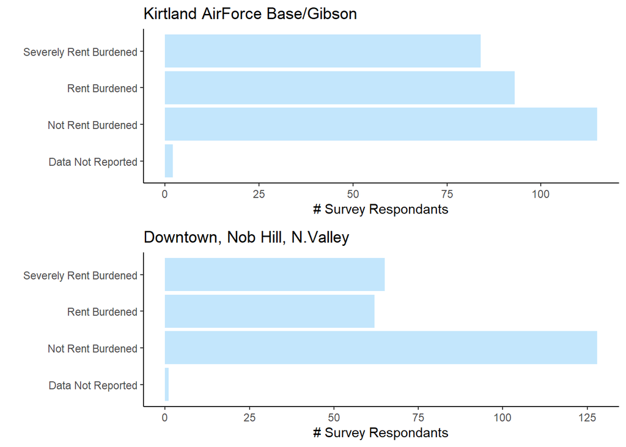

```r
plot_grid(RB_KAFB, RB_DT, ncol=1, align="v")
```

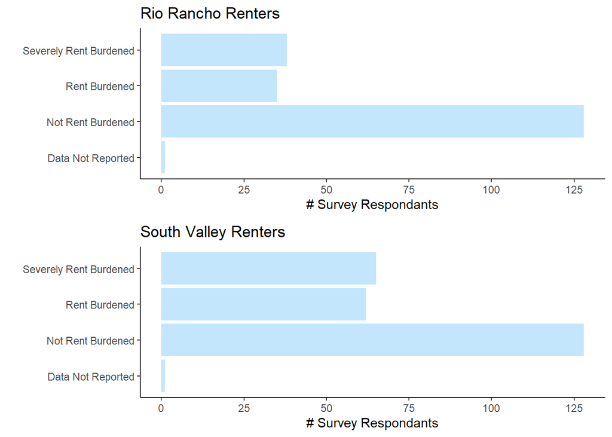

```r
plot_grid(RB_RR, RB_SV, ncol=1, align="v")
```

#### **2. Race & Ethnicity**

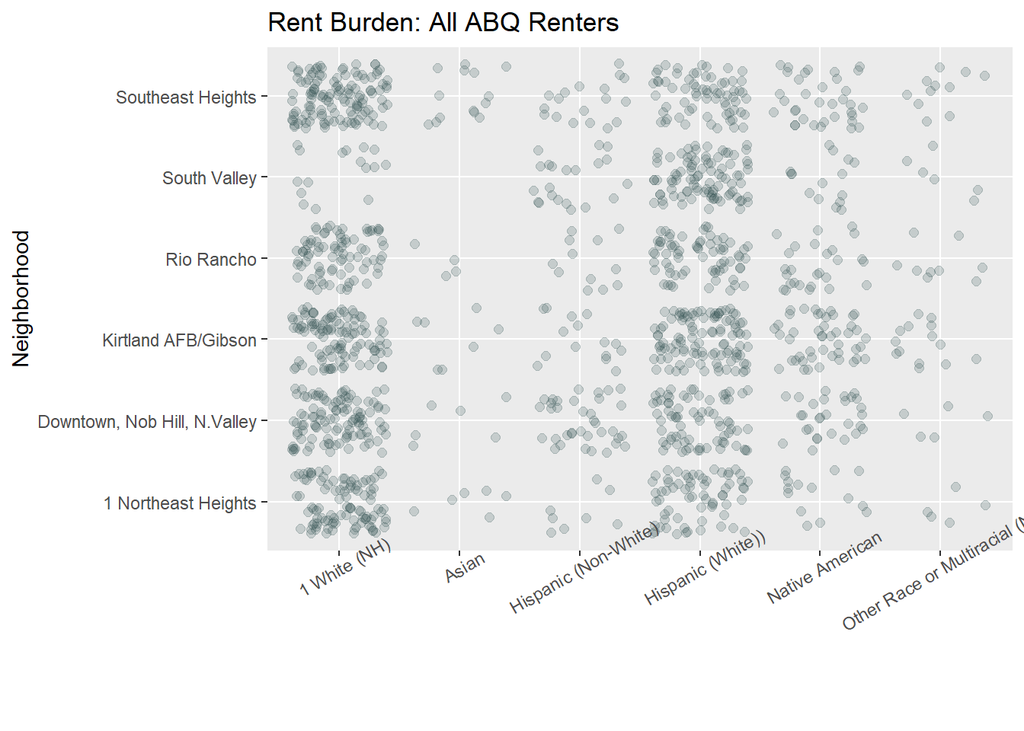

```r
ggplot(ass6_ABQs_renters, aes(x=race_ethn, y=PUMA_label)) +


  labs(title="Rent Burden: All ABQ Renters")  +
  geom_point(position = "jitter", size =2, alpha =.2, color = "darkslategray") +
  scale_y_discrete(name="Neighborhood") +
  scale_x_discrete(name ="") +
  theme(axis.text.x = element_text(angle = 30))
```

```r
   theme_minimal()
```

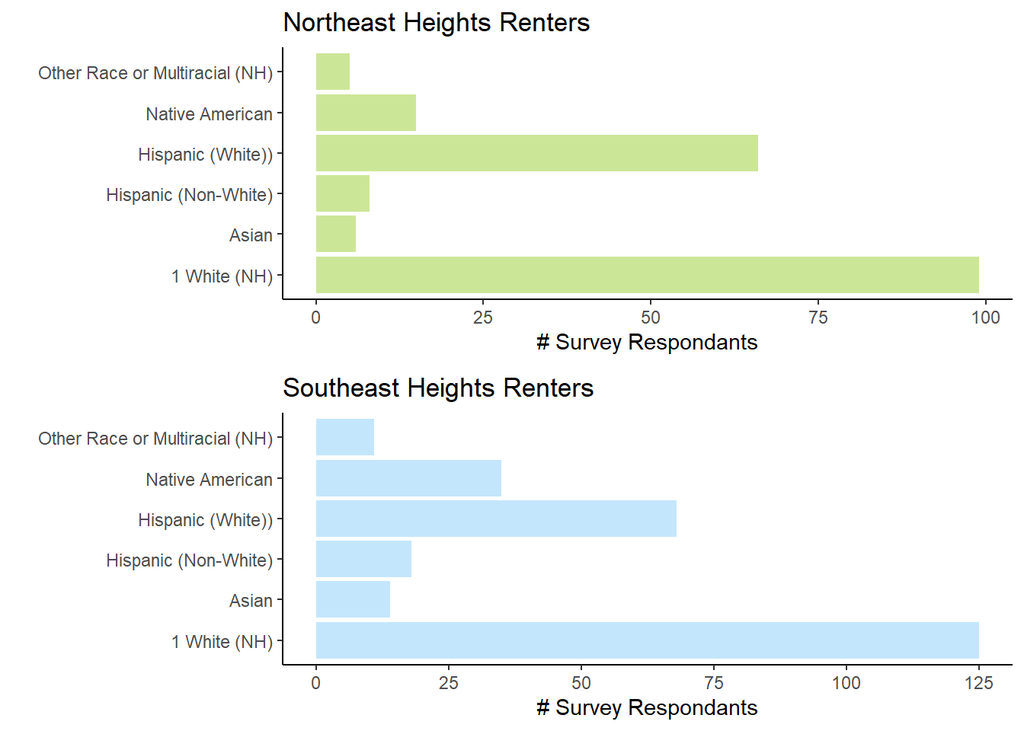

```r
RE_NEH <-  ggplot(ass6_NEHeights_renters, aes(x =race_ethn)) +
   labs(title="Northeast Heights Renters")  +
  geom_bar(fill="olivedrab3", alpha =.5) +
   theme(axis.text.x = element_text(angle = 90)) +
   scale_x_discrete(name="") +
    scale_y_continuous(name= "# Survey Respondants",
                       breaks = seq(0,1000, by = 25),
                     labels = paste(seq(0,1000, by = 25),
                     "", sep = "")) +
   coord_flip() +
  theme_classic()


RE_SEH <-  ggplot(ass6_SEHeights_renters, aes(x =race_ethn)) +
   labs(title="Southeast Heights Renters")  +
  geom_bar(fill="lightskyblue", alpha =.5) +
   theme(axis.text.x = element_text(angle = 90)) +
   scale_x_discrete(name="") +
       scale_y_continuous(name= "# Survey Respondants",
                       breaks = seq(0,1000, by = 25),
                     labels = paste(seq(0,1000, by = 25),
                     "", sep = "")) +
   coord_flip() +
  theme_classic()



RE_KAFB <-  ggplot(ass6_KAFB_renters, aes(x =race_ethn)) +
   labs(title="Kirtland AirForce Base/Gibson")  +
  geom_bar(fill="lightskyblue", alpha =.5) +
   theme(axis.text.x = element_text(angle = 90)) +
   scale_x_discrete(name="") +
       scale_y_continuous(name= "# Survey Respondants",
                       breaks = seq(0,1000, by = 25),
                     labels = paste(seq(0,1000, by = 25),
                     "", sep = "")) +
   coord_flip() +
  theme_classic()


RE_DT <-  ggplot(ass6_DT_NH_NV_renters, aes(x =race_ethn)) +
   labs(title="Downtown, Nob Hill, N.Valley")  +
  geom_bar(fill="lightskyblue", alpha =.5) +
   theme(axis.text.x = element_text(angle = 90)) +
   scale_x_discrete(name="") +
       scale_y_continuous(name= "# Survey Respondants",
                       breaks = seq(0,1000, by = 25),
                     labels = paste(seq(0,1000, by = 25),
                     "", sep = "")) +
   coord_flip() +
  theme_classic()

RE_RR <-  ggplot(ass6_RIO_R_renters, aes(x =race_ethn)) +
   labs(title="Rio Rancho Renters")  +
  geom_bar(fill="lightskyblue", alpha =.5) +
   theme(axis.text.x = element_text(angle = 90)) +
   scale_x_discrete(name="") +
       scale_y_continuous(name= "# Survey Respondants",
                       breaks = seq(0,1000, by = 25),
                     labels = paste(seq(0,1000, by = 25),
                     "", sep = "")) +
   coord_flip() +
  theme_classic()

RE_SV <-  ggplot(ass6_DT_NH_NV_renters, aes(x =race_ethn)) +
   labs(title="South Valley Renters")  +
  geom_bar(fill="lightskyblue", alpha =.5) +
   theme(axis.text.x = element_text(angle = 30)) +
   scale_x_discrete(name="") +
       scale_y_continuous(name= "# Survey Respondants",
                       breaks = seq(0,1000, by = 25),
                     labels = paste(seq(0,1000, by = 25),
                     "", sep = "")) +
   coord_flip() +
  theme_classic()

plot_grid(RE_NEH, RE_SEH, ncol=1, align="v")
```

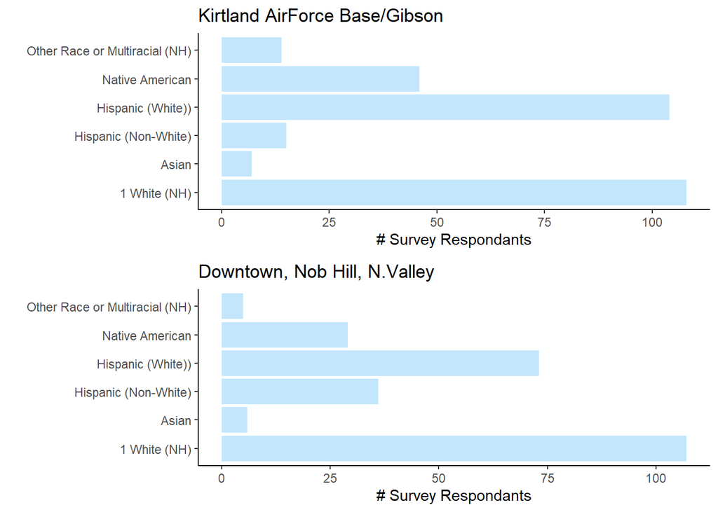

```r
plot_grid(RE_KAFB, RE_DT, ncol=1, align="v")
```

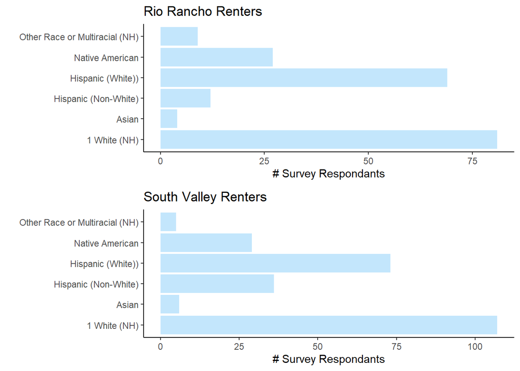

```r
plot_grid(RE_RR, RE_SV, ncol=1, align="v")
```

#### **3. Commute Time to Work**

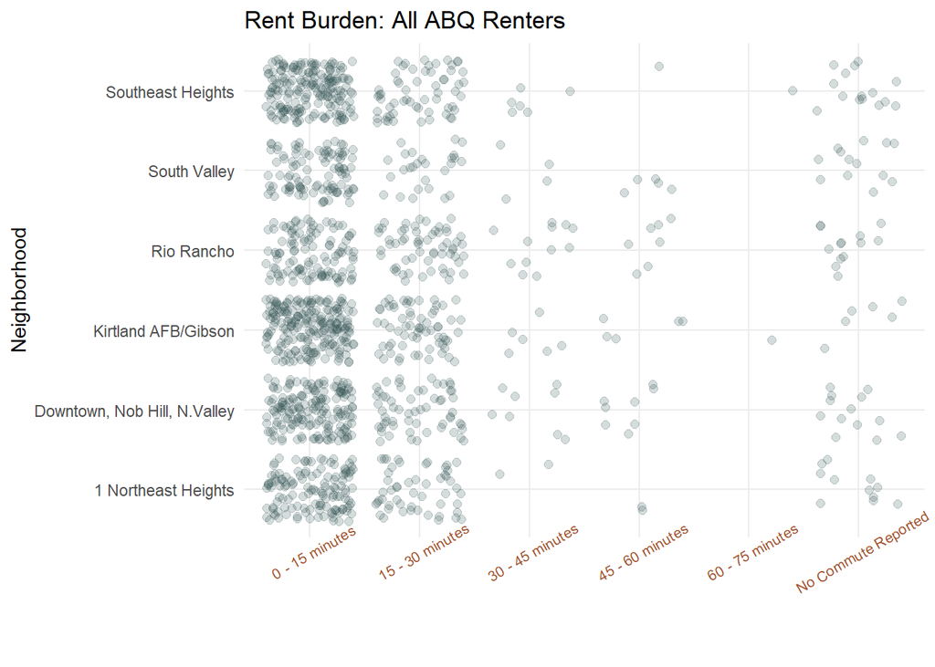

```r
ggplot(ass6_ABQs_renters, aes(x=JWMNP_binned, y=PUMA_label)) +


  labs(title="Rent Burden: All ABQ Renters")  +
  geom_point(position = "jitter", size =2, alpha =.2, color = "darkslategray") +
  scale_y_discrete(name="Neighborhood") +
  scale_x_discrete(name ="") +
  theme_minimal() +
  theme(axis.text.x = element_text(angle = 30, color="sienna", size =8))
```

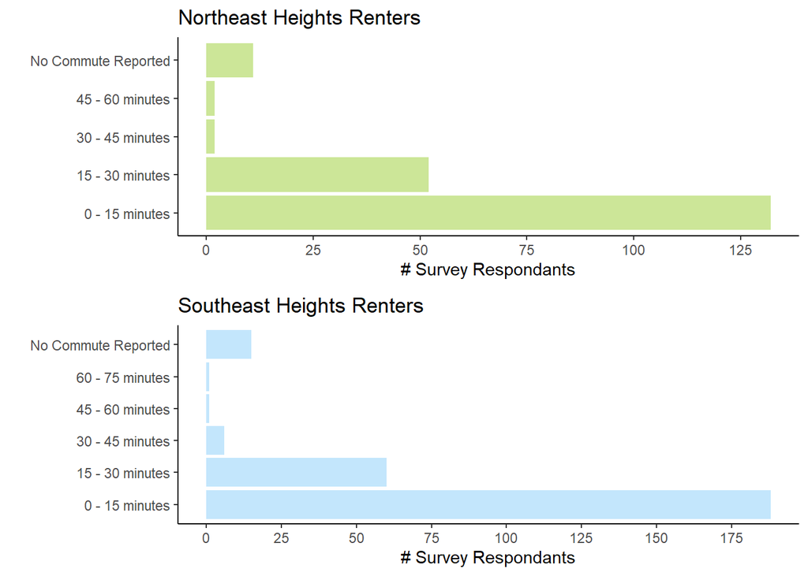

```r
JW_NEH <-  ggplot(ass6_NEHeights_renters, aes(x =JWMNP_binned)) +
   labs(title="Northeast Heights Renters")  +
  geom_bar(fill="olivedrab3", alpha =.5) +
   theme(axis.text.x = element_text(angle = 90)) +
   scale_x_discrete(name="") +
    scale_y_continuous(name= "# Survey Respondants",
                       breaks = seq(0,1000, by = 25),
                     labels = paste(seq(0,1000, by = 25),
                     "", sep = "")) +
   coord_flip() +
  theme_classic()


JW_SEH <-  ggplot(ass6_SEHeights_renters, aes(x =JWMNP_binned)) +
   labs(title="Southeast Heights Renters")  +
  geom_bar(fill="lightskyblue", alpha =.5) +
   theme(axis.text.x = element_text(angle = 90)) +
   scale_x_discrete(name="") +
       scale_y_continuous(name= "# Survey Respondants",
                       breaks = seq(0,1000, by = 25),
                     labels = paste(seq(0,1000, by = 25),
                     "", sep = "")) +
   coord_flip() +
  theme_classic()



JW_KAFB <-  ggplot(ass6_KAFB_renters, aes(x =JWMNP_binned)) +
   labs(title="Kirtland AirForce Base/Gibson")  +
  geom_bar(fill="lightskyblue", alpha =.5) +
   theme(axis.text.x = element_text(angle = 90)) +
   scale_x_discrete(name="") +
       scale_y_continuous(name= "# Survey Respondants",
                       breaks = seq(0,1000, by = 25),
                     labels = paste(seq(0,1000, by = 25),
                     "", sep = "")) +
   coord_flip() +
  theme_classic()


JW_DT <-  ggplot(ass6_DT_NH_NV_renters, aes(x =JWMNP_binned)) +
   labs(title="Downtown, Nob Hill, N.Valley")  +
  geom_bar(fill="lightskyblue", alpha =.5) +
   theme(axis.text.x = element_text(angle = 90)) +
   scale_x_discrete(name="") +
       scale_y_continuous(name= "# Survey Respondants",
                       breaks = seq(0,1000, by = 25),
                     labels = paste(seq(0,1000, by = 25),
                     "", sep = "")) +
   coord_flip() +
  theme_classic()

JW_RR <-  ggplot(ass6_RIO_R_renters, aes(x =JWMNP_binned)) +
   labs(title="Rio Rancho Renters")  +
  geom_bar(fill="lightskyblue", alpha =.5) +
   theme(axis.text.x = element_text(angle = 90)) +
   scale_x_discrete(name="") +
       scale_y_continuous(name= "# Survey Respondants",
                       breaks = seq(0,1000, by = 25),
                     labels = paste(seq(0,1000, by = 25),
                     "", sep = "")) +
   coord_flip() +
  theme_classic()

JW_SV <-  ggplot(ass6_DT_NH_NV_renters, aes(x =JWMNP_binned)) +
   labs(title="South Valley Renters")  +
  geom_bar(fill="lightskyblue", alpha =.5) +
   theme(axis.text.x = element_text(angle = 90)) +
   scale_x_discrete(name="") +
       scale_y_continuous(name= "# Survey Respondants",
                       breaks = seq(0,1000, by = 25),
                     labels = paste(seq(0,1000, by = 25),
                     "", sep = "")) +
   coord_flip() +
  theme_classic()

plot_grid(JW_NEH, JW_SEH, ncol=1, align="v")
```

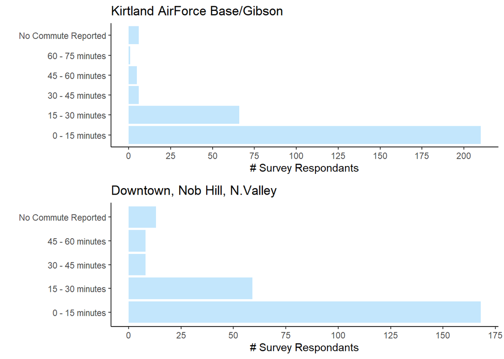

```r
plot_grid(JW_KAFB, JW_DT, ncol=1, align="v")
```

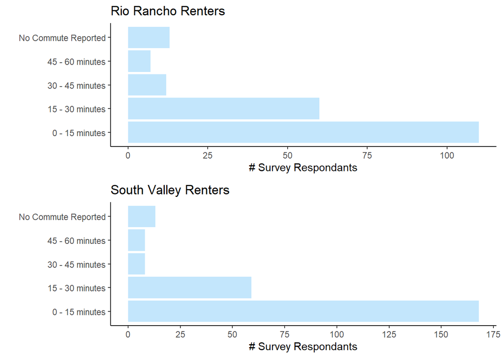

```r
plot_grid(JW_RR, JW_SV, ncol=1, align="v")
```

#### **4. # People in Household**

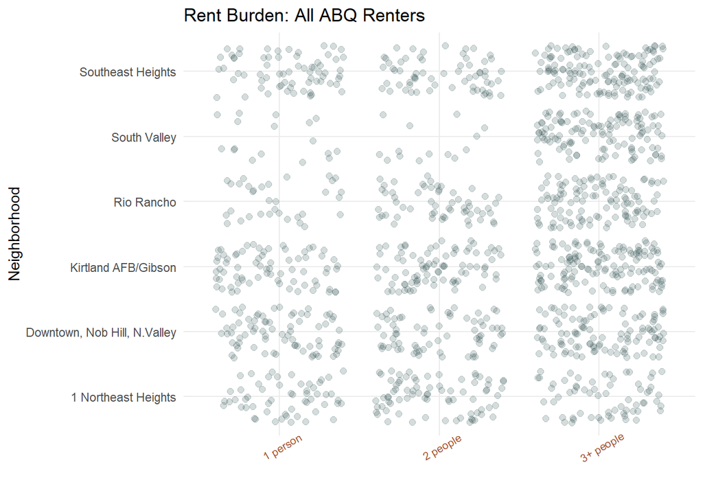

```r
ggplot(ass6_ABQs_renters, aes(x=NP_simp, y=PUMA_label)) +


  labs(title="Rent Burden: All ABQ Renters")  +
  geom_point(position = "jitter", size =2, alpha =.2, color = "darkslategray") +
  scale_y_discrete(name="Neighborhood") +
  scale_x_discrete(name ="") +
  theme_minimal() +
  theme(axis.text.x = element_text(angle = 30, color="sienna", size =8))
```

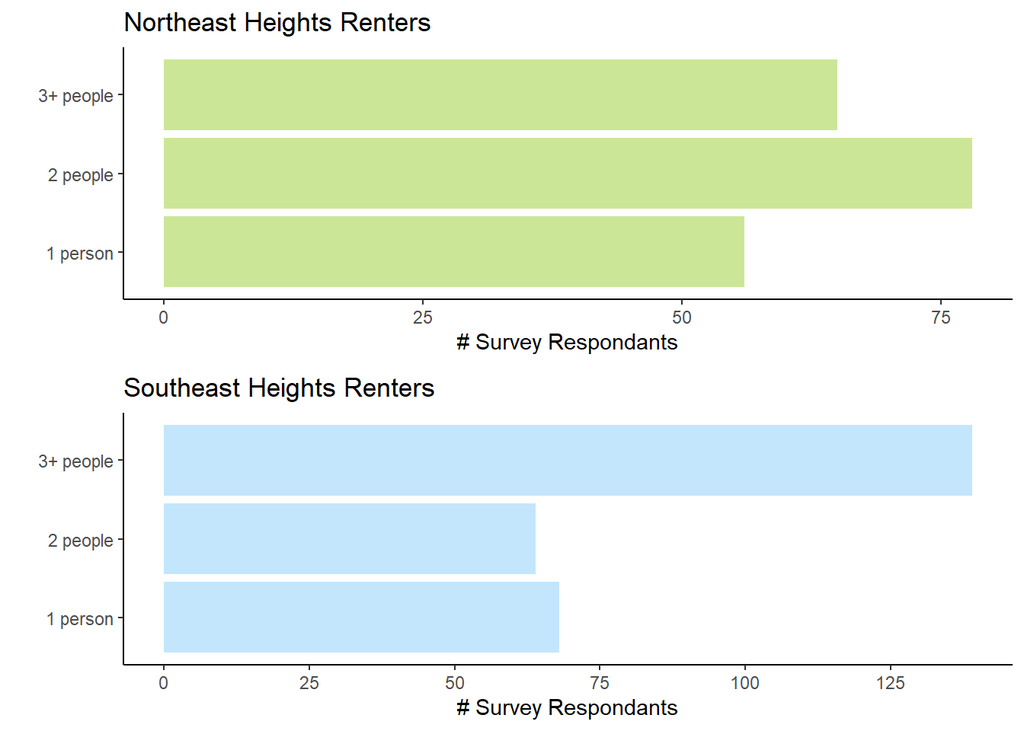

```r
NP_NEH <-  ggplot(ass6_NEHeights_renters, aes(x =NP_simp)) +
   labs(title="Northeast Heights Renters")  +
  geom_bar(fill="olivedrab3", alpha =.5) +
   theme(axis.text.x = element_text(angle = 90)) +
   scale_x_discrete(name="") +
    scale_y_continuous(name= "# Survey Respondants",
                       breaks = seq(0,1000, by = 25),
                     labels = paste(seq(0,1000, by = 25),
                     "", sep = "")) +
   coord_flip() +
  theme_classic()


NP_SEH <-  ggplot(ass6_SEHeights_renters, aes(x =NP_simp)) +
   labs(title="Southeast Heights Renters")  +
  geom_bar(fill="lightskyblue", alpha =.5) +
   theme(axis.text.x = element_text(angle = 90)) +
   scale_x_discrete(name="") +
       scale_y_continuous(name= "# Survey Respondants",
                       breaks = seq(0,1000, by = 25),
                     labels = paste(seq(0,1000, by = 25),
                     "", sep = "")) +
   coord_flip() +
  theme_classic()



NP_KAFB <-  ggplot(ass6_KAFB_renters, aes(x =NP_simp)) +
   labs(title="Kirtland AirForce Base/Gibson")  +
  geom_bar(fill="lightskyblue", alpha =.5) +
   theme(axis.text.x = element_text(angle = 90)) +
   scale_x_discrete(name="") +
       scale_y_continuous(name= "# Survey Respondants",
                       breaks = seq(0,1000, by = 25),
                     labels = paste(seq(0,1000, by = 25),
                     "", sep = "")) +
   coord_flip() +
  theme_classic()


NP_DT <-  ggplot(ass6_DT_NH_NV_renters, aes(x =NP_simp)) +
   labs(title="Downtown, Nob Hill, N.Valley")  +
  geom_bar(fill="lightskyblue", alpha =.5) +
   theme(axis.text.x = element_text(angle = 90)) +
   scale_x_discrete(name="") +
       scale_y_continuous(name= "# Survey Respondants",
                       breaks = seq(0,1000, by = 25),
                     labels = paste(seq(0,1000, by = 25),
                     "", sep = "")) +
   coord_flip() +
  theme_classic()

NP_RR <-  ggplot(ass6_RIO_R_renters, aes(x =NP_simp)) +
   labs(title="Rio Rancho Renters")  +
  geom_bar(fill="lightskyblue", alpha =.5) +
   theme(axis.text.x = element_text(angle = 90)) +
   scale_x_discrete(name="") +
       scale_y_continuous(name= "# Survey Respondants",
                       breaks = seq(0,1000, by = 25),
                     labels = paste(seq(0,1000, by = 25),
                     "", sep = "")) +
   coord_flip() +
  theme_classic()

NP_SV <-  ggplot(ass6_DT_NH_NV_renters, aes(x =NP_simp)) +
   labs(title="South Valley Renters")  +
  geom_bar(fill="lightskyblue", alpha =.5) +
   theme(axis.text.x = element_text(angle = 90)) +
   scale_x_discrete(name="") +
       scale_y_continuous(name= "# Survey Respondants",
                       breaks = seq(0,1000, by = 25),
                     labels = paste(seq(0,1000, by = 25),
                     "", sep = "")) +
   coord_flip() +
  theme_classic()

plot_grid(NP_NEH, NP_SEH, ncol=1, align="v")
```

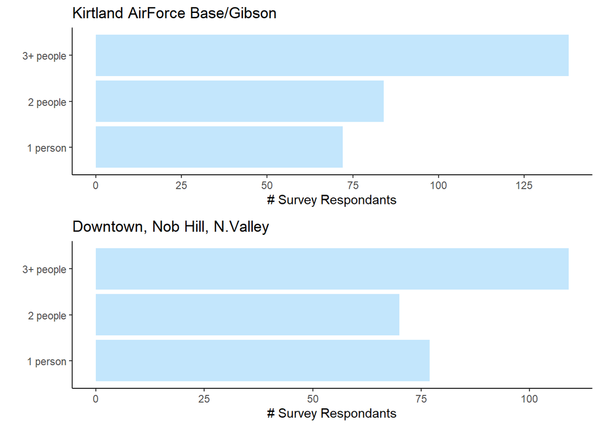

```r
plot_grid(NP_KAFB, NP_DT, ncol=1, align="v")
```

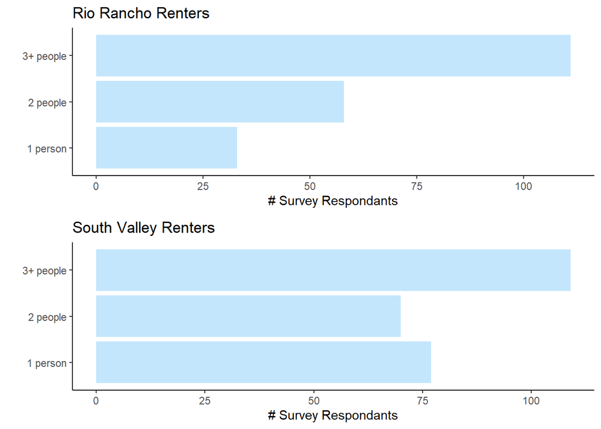

```r
plot_grid(NP_RR, NP_SV, ncol=1, align="v")
```

#### **5. Rental Type**

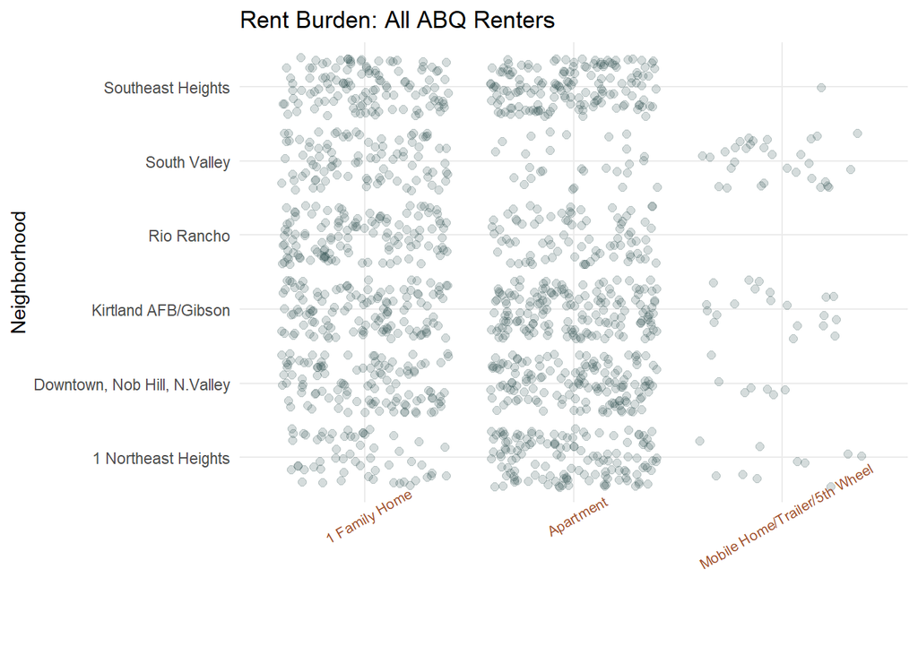

```r
ggplot(ass6_ABQs_renters, aes(x=bld_type, y=PUMA_label)) +


  labs(title="Rent Burden: All ABQ Renters")  +
  geom_point(position = "jitter", size =2, alpha =.2, color = "darkslategray") +
  scale_y_discrete(name="Neighborhood") +
  scale_x_discrete(name ="") +
  theme_minimal() +
  theme(axis.text.x = element_text(angle = 30, color="sienna", size =8))
```

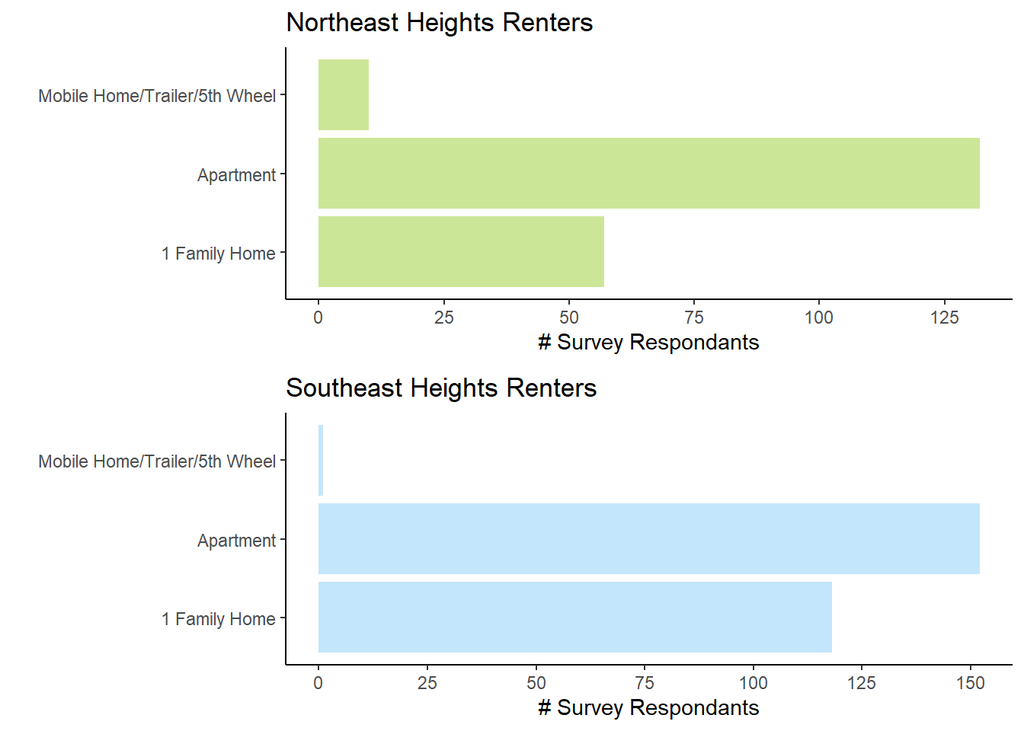

```r
BT_NEH <-  ggplot(ass6_NEHeights_renters, aes(x =bld_type)) +
   labs(title="Northeast Heights Renters")  +
  geom_bar(fill="olivedrab3", alpha =.5) +
   theme(axis.text.x = element_text(angle = 90)) +
   scale_x_discrete(name="") +
    scale_y_continuous(name= "# Survey Respondants",
                       breaks = seq(0,1000, by = 25),
                     labels = paste(seq(0,1000, by = 25),
                     "", sep = "")) +
   coord_flip() +
  theme_classic()


BT_SEH <-  ggplot(ass6_SEHeights_renters, aes(x =bld_type)) +
   labs(title="Southeast Heights Renters")  +
  geom_bar(fill="lightskyblue", alpha =.5) +
   theme(axis.text.x = element_text(angle = 90)) +
   scale_x_discrete(name="") +
       scale_y_continuous(name= "# Survey Respondants",
                       breaks = seq(0,1000, by = 25),
                     labels = paste(seq(0,1000, by = 25),
                     "", sep = "")) +
   coord_flip() +
  theme_classic()



BT_KAFB <-  ggplot(ass6_KAFB_renters, aes(x =bld_type)) +
   labs(title="Kirtland AirForce Base/Gibson")  +
  geom_bar(fill="lightskyblue", alpha =.5) +
   theme(axis.text.x = element_text(angle = 90)) +
   scale_x_discrete(name="") +
       scale_y_continuous(name= "# Survey Respondants",
                       breaks = seq(0,1000, by = 25),
                     labels = paste(seq(0,1000, by = 25),
                     "", sep = "")) +
   coord_flip() +
  theme_classic()


BT_DT <-  ggplot(ass6_DT_NH_NV_renters, aes(x =bld_type)) +
   labs(title="Downtown, Nob Hill, N.Valley")  +
  geom_bar(fill="lightskyblue", alpha =.5) +
   theme(axis.text.x = element_text(angle = 90)) +
   scale_x_discrete(name="") +
       scale_y_continuous(name= "# Survey Respondants",
                       breaks = seq(0,1000, by = 25),
                     labels = paste(seq(0,1000, by = 25),
                     "", sep = "")) +
   coord_flip() +
  theme_classic()

BT_RR <-  ggplot(ass6_RIO_R_renters, aes(x =bld_type)) +
   labs(title="Rio Rancho Renters")  +
  geom_bar(fill="lightskyblue", alpha =.5) +
   theme(axis.text.x = element_text(angle = 90)) +
   scale_x_discrete(name="") +
       scale_y_continuous(name= "# Survey Respondants",
                       breaks = seq(0,1000, by = 25),
                     labels = paste(seq(0,1000, by = 25),
                     "", sep = "")) +
   coord_flip() +
  theme_classic()

BT_SV <-  ggplot(ass6_DT_NH_NV_renters, aes(x =bld_type)) +
   labs(title="South Valley Renters")  +
  geom_bar(fill="lightskyblue", alpha =.5) +
   theme(axis.text.x = element_text(angle = 90)) +
   scale_x_discrete(name="") +
       scale_y_continuous(name= "# Survey Respondants",
                       breaks = seq(0,1000, by = 25),
                     labels = paste(seq(0,1000, by = 25),
                     "", sep = "")) +
   coord_flip() +
  theme_classic()

plot_grid(BT_NEH, BT_SEH, ncol=1, align="v")
```

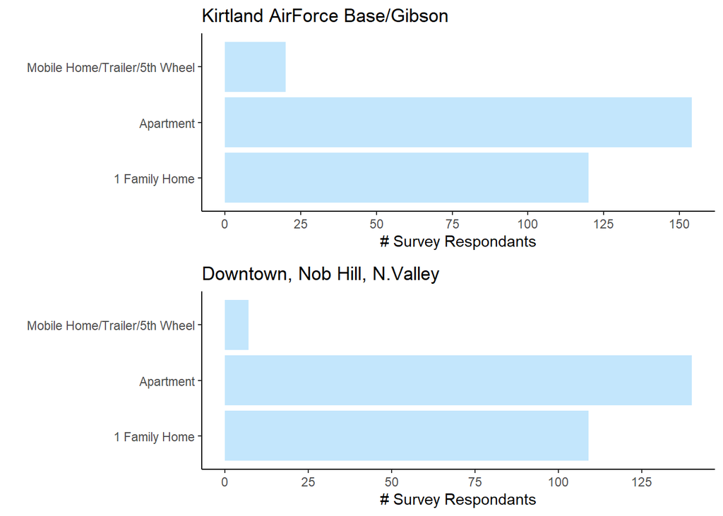

```r
plot_grid(BT_KAFB, BT_DT, ncol=1, align="v")
```

[figure not shown]

```r
plot_grid(BT_RR, BT_SV, ncol=1, align="v")
```

#### **6. Decade Constructed**

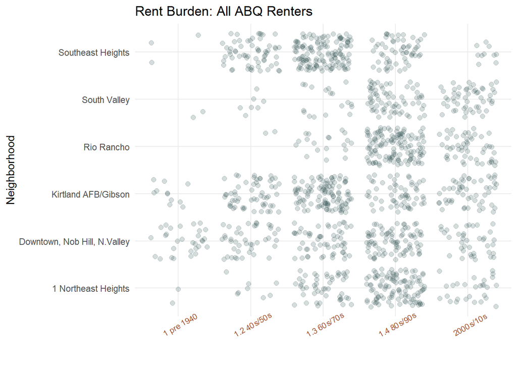

```r
ggplot(ass6_ABQs_renters, aes(x=when_built, y=PUMA_label)) +


  labs(title="Rent Burden: All ABQ Renters")  +
  geom_point(position = "jitter", size =2, alpha =.2, color = "darkslategray") +
  scale_y_discrete(name="Neighborhood") +
  scale_x_discrete(name ="") +
  theme_minimal() +
  theme(axis.text.x = element_text(angle = 30, color="sienna", size =8))
```

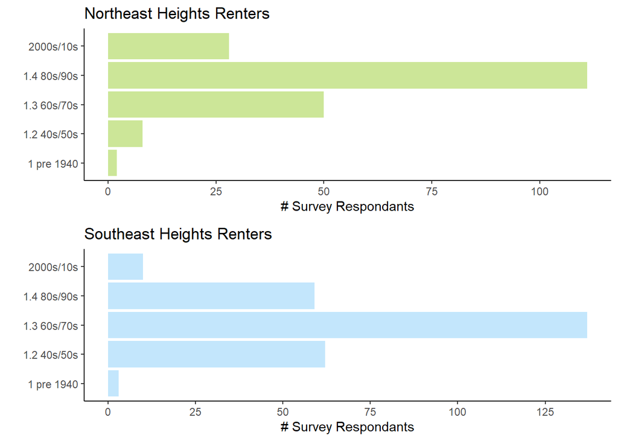

```r
WB_NEH <-  ggplot(ass6_NEHeights_renters, aes(x =when_built)) +
   labs(title="Northeast Heights Renters")  +
  geom_bar(fill="olivedrab3", alpha =.5) +
   theme(axis.text.x = element_text(angle = 90)) +
   scale_x_discrete(name="") +
    scale_y_continuous(name= "# Survey Respondants",
                       breaks = seq(0,1000, by = 25),
                     labels = paste(seq(0,1000, by = 25),
                     "", sep = "")) +
   coord_flip() +
  theme_classic()


WB_SEH <-  ggplot(ass6_SEHeights_renters, aes(x =when_built)) +
   labs(title="Southeast Heights Renters")  +
  geom_bar(fill="lightskyblue", alpha =.5) +
   theme(axis.text.x = element_text(angle = 90)) +
   scale_x_discrete(name="") +
       scale_y_continuous(name= "# Survey Respondants",
                       breaks = seq(0,1000, by = 25),
                     labels = paste(seq(0,1000, by = 25),
                     "", sep = "")) +
   coord_flip() +
  theme_classic()



WB_KAFB <-  ggplot(ass6_KAFB_renters, aes(x =when_built)) +
   labs(title="Kirtland AirForce Base/Gibson")  +
  geom_bar(fill="lightskyblue", alpha =.5) +
   theme(axis.text.x = element_text(angle = 90)) +
   scale_x_discrete(name="") +
       scale_y_continuous(name= "# Survey Respondants",
                       breaks = seq(0,1000, by = 25),
                     labels = paste(seq(0,1000, by = 25),
                     "", sep = "")) +
   coord_flip() +
  theme_classic()


WB_DT <-  ggplot(ass6_DT_NH_NV_renters, aes(x =when_built)) +
   labs(title="Downtown, Nob Hill, N.Valley")  +
  geom_bar(fill="lightskyblue", alpha =.5) +
   theme(axis.text.x = element_text(angle = 90)) +
   scale_x_discrete(name="") +
       scale_y_continuous(name= "# Survey Respondants",
                       breaks = seq(0,1000, by = 25),
                     labels = paste(seq(0,1000, by = 25),
                     "", sep = "")) +
   coord_flip() +
  theme_classic()

WB_RR <-  ggplot(ass6_RIO_R_renters, aes(x =when_built)) +
   labs(title="Rio Rancho Renters")  +
  geom_bar(fill="lightskyblue", alpha =.5) +
   theme(axis.text.x = element_text(angle = 90)) +
   scale_x_discrete(name="") +
       scale_y_continuous(name= "# Survey Respondants",
                       breaks = seq(0,1000, by = 25),
                     labels = paste(seq(0,1000, by = 25),
                     "", sep = "")) +
   coord_flip() +
  theme_classic()

WB_SV <-  ggplot(ass6_DT_NH_NV_renters, aes(x =when_built)) +
   labs(title="South Valley Renters")  +
  geom_bar(fill="lightskyblue", alpha =.5) +
   theme(axis.text.x = element_text(angle = 90)) +
   scale_x_discrete(name="") +
       scale_y_continuous(name= "# Survey Respondants",
                       breaks = seq(0,1000, by = 25),
                     labels = paste(seq(0,1000, by = 25),
                     "", sep = "")) +
   coord_flip() +
  theme_classic()

plot_grid(WB_NEH, WB_SEH, ncol=1, align="v")
```

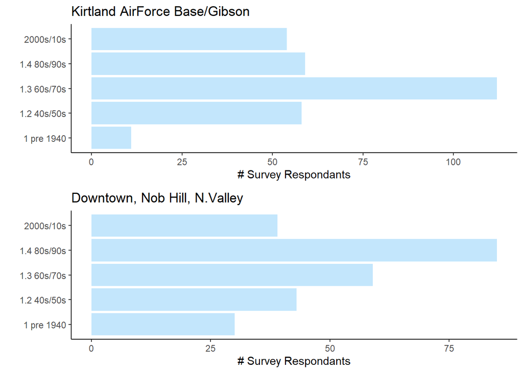

```r
plot_grid(WB_KAFB, WB_DT, ncol=1, align="v")
```

[figure not shown]

```r
plot_grid(WB_RR, WB_SV, ncol=1, align="v")
```

#### **6. Education**

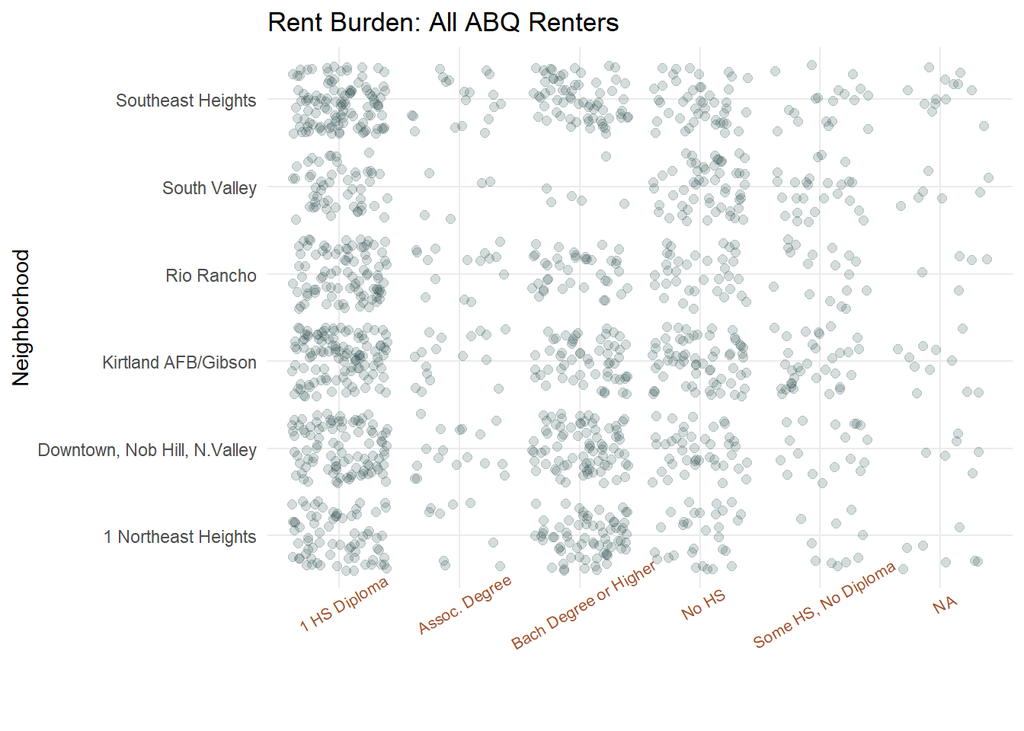

```r
ggplot(ass6_ABQs_renters, aes(x=SCHL_simp, y=PUMA_label)) +


  labs(title="Rent Burden: All ABQ Renters")  +
  geom_point(position = "jitter", size =2, alpha =.2, color = "darkslategray") +
  scale_y_discrete(name="Neighborhood") +
  scale_x_discrete(name ="") +
  theme_minimal() +
  theme(axis.text.x = element_text(angle = 30, color="sienna", size =8))
```

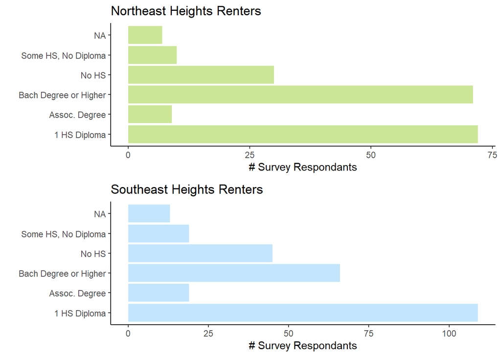

```r
WB_NEH <-  ggplot(ass6_NEHeights_renters, aes(x =SCHL_simp)) +
   labs(title="Northeast Heights Renters")  +
  geom_bar(fill="olivedrab3", alpha =.5) +
   theme(axis.text.x = element_text(angle = 90)) +
   scale_x_discrete(name="") +
    scale_y_continuous(name= "# Survey Respondants",
                       breaks = seq(0,1000, by = 25),
                     labels = paste(seq(0,1000, by = 25),
                     "", sep = "")) +
   coord_flip() +
  theme_classic()


WB_SEH <-  ggplot(ass6_SEHeights_renters, aes(x =SCHL_simp)) +
   labs(title="Southeast Heights Renters")  +
  geom_bar(fill="lightskyblue", alpha =.5) +
   theme(axis.text.x = element_text(angle = 90)) +
   scale_x_discrete(name="") +
       scale_y_continuous(name= "# Survey Respondants",
                       breaks = seq(0,1000, by = 25),
                     labels = paste(seq(0,1000, by = 25),
                     "", sep = "")) +
   coord_flip() +
  theme_classic()



WB_KAFB <-  ggplot(ass6_KAFB_renters, aes(x =SCHL_simp)) +
   labs(title="Kirtland AirForce Base/Gibson")  +
  geom_bar(fill="lightskyblue", alpha =.5) +
   theme(axis.text.x = element_text(angle = 90)) +
   scale_x_discrete(name="") +
       scale_y_continuous(name= "# Survey Respondants",
                       breaks = seq(0,1000, by = 25),
                     labels = paste(seq(0,1000, by = 25),
                     "", sep = "")) +
   coord_flip() +
  theme_classic()


WB_DT <-  ggplot(ass6_DT_NH_NV_renters, aes(x =SCHL_simp)) +
   labs(title="Downtown, Nob Hill, N.Valley")  +
  geom_bar(fill="lightskyblue", alpha =.5) +
   theme(axis.text.x = element_text(angle = 90)) +
   scale_x_discrete(name="") +
       scale_y_continuous(name= "# Survey Respondants",
                       breaks = seq(0,1000, by = 25),
                     labels = paste(seq(0,1000, by = 25),
                     "", sep = "")) +
   coord_flip() +
  theme_classic()

WB_RR <-  ggplot(ass6_RIO_R_renters, aes(x =SCHL_simp)) +
   labs(title="Rio Rancho Renters")  +
  geom_bar(fill="lightskyblue", alpha =.5) +
   theme(axis.text.x = element_text(angle = 90)) +
   scale_x_discrete(name="") +
       scale_y_continuous(name= "# Survey Respondants",
                       breaks = seq(0,1000, by = 25),
                     labels = paste(seq(0,1000, by = 25),
                     "", sep = "")) +
   coord_flip() +
  theme_classic()

WB_SV <-  ggplot(ass6_DT_NH_NV_renters, aes(x =SCHL_simp)) +
   labs(title="South Valley Renters")  +
  geom_bar(fill="lightskyblue", alpha =.5) +
   theme(axis.text.x = element_text(angle = 90)) +
   scale_x_discrete(name="") +
       scale_y_continuous(name= "# Survey Respondants",
                       breaks = seq(0,1000, by = 25),
                     labels = paste(seq(0,1000, by = 25),
                     "", sep = "")) +
   coord_flip() +
  theme_classic()

plot_grid(WB_NEH, WB_SEH, ncol=1, align="v")
```

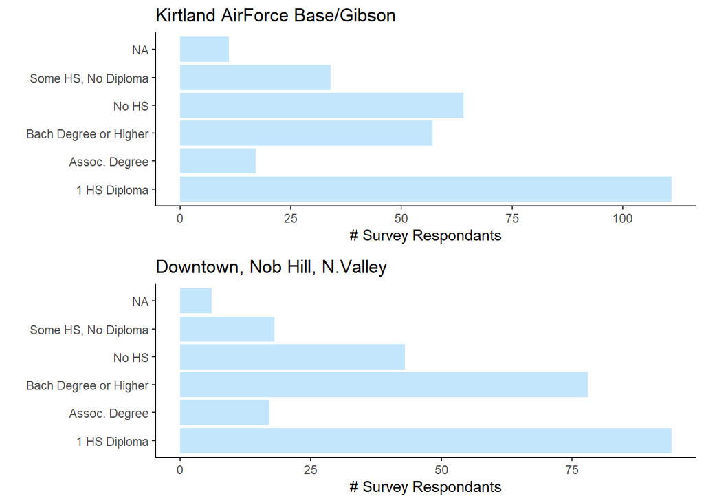

```r
plot_grid(WB_KAFB, WB_DT, ncol=1, align="v")
```

[figure not shown]

```r
plot_grid(WB_RR, WB_SV, ncol=1, align="v")
```

#### **8. Income**

```r
HINCP_hist <- ggplot(ass6_ABQs_renters, aes(HINCP)) +
  scale_fill_brewer(palette = "Spectral") +
  geom_histogram(aes(fill= PUMA_label)) +
  labs(title="Household Income Dist of ABQ Renters")  +
  scale_y_continuous(name="Number of Respondents") +
  scale_x_continuous(name="Household Income") +
  theme_minimal()
```

```r
PINCP_hist <- ggplot(ass6_ABQs_renters, aes(PINCP)) +
  scale_fill_brewer(palette = "Spectral") +
  geom_histogram(aes(fill= PUMA_label)) +
  labs(title="Individual Income Dist of ABQ Renters")  +
  scale_y_continuous(name="Number of Respondents") +
  scale_x_continuous(name="Personal Income")+
  theme_minimal()
```

```r
income_per_person_hist <- ggplot(ass6_ABQs_renters, aes(income_per_person)) +
  scale_fill_brewer(palette = "Spectral") +
  geom_histogram(aes(fill= PUMA_label)) +
  labs(title="Household Income Per Person Dist of ABQ Renters")  +
  scale_y_continuous(name="Number of Respondents") +
  scale_x_continuous(name="Personal Income") +
  theme_minimal()
```

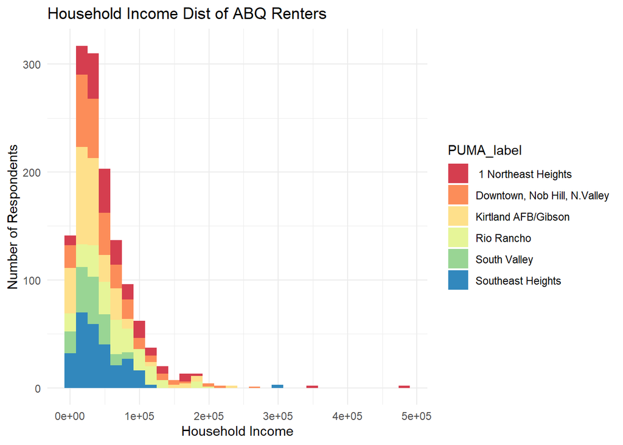

```r
HINCP_hist
```

```r
summary(ass6_ABQs_renters$HINCP)
```

```
##    Min. 1st Qu.  Median    Mean 3rd Qu.    Max.
##   -1700   19575   35000   47918   65000  480000
```

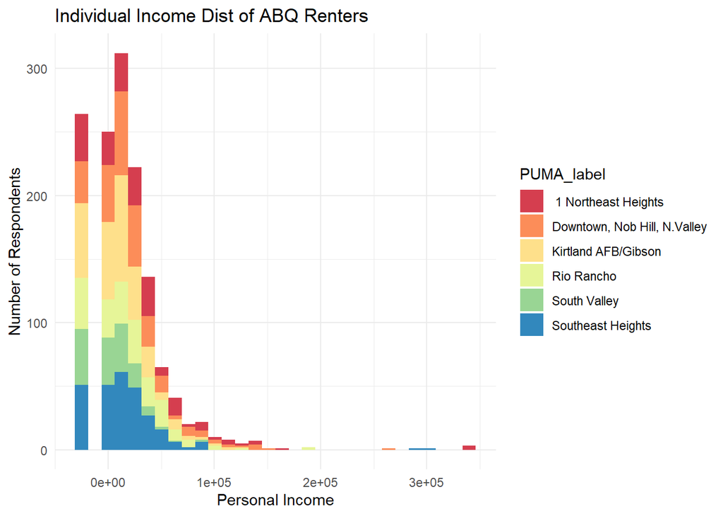

```r
PINCP_hist
```

```r
summary(ass6_ABQs_renters$PINCP)
```

```
##    Min. 1st Qu.  Median    Mean 3rd Qu.    Max.
##  -19999       0   12650   17980   30000  345000
```

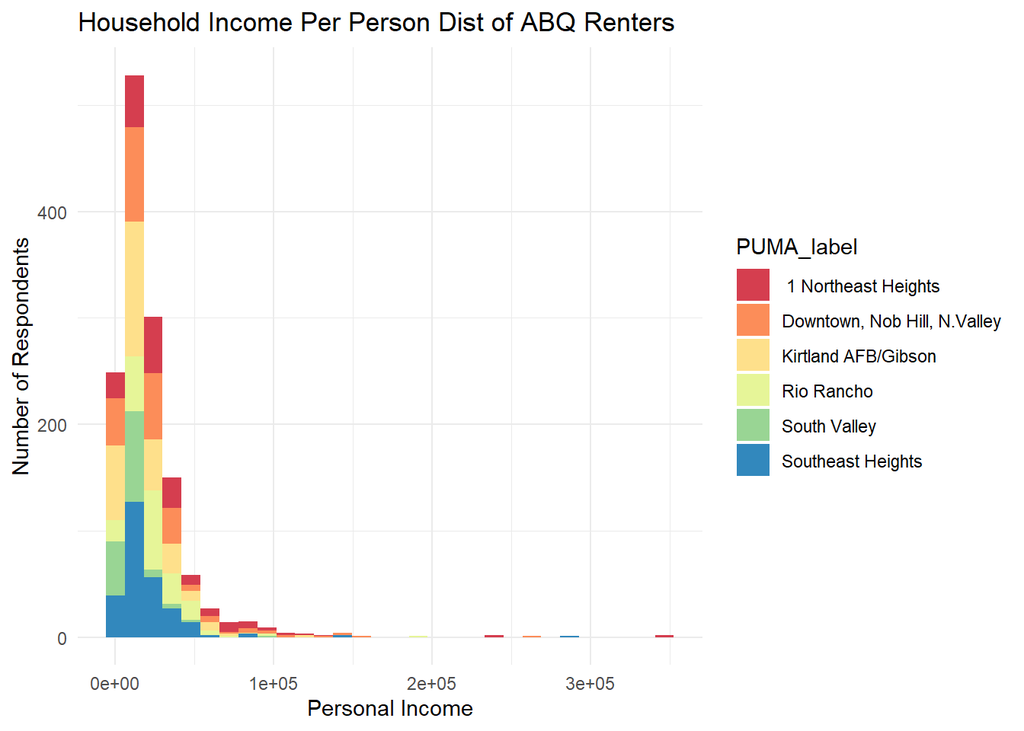

```r
income_per_person_hist
```

```r
summary(ass6_ABQs_renters$income_per_person)
```

```
##    Min. 1st Qu.  Median    Mean 3rd Qu.    Max.
##   -1700    7625   15650   21828   27375  345000
```